Class, the below is a standard set of instructions for each HW, in this assignment groups will be set up for collaboration.  
Make sure your group starts one thread for the collaborative problems. You are required to participate in the collaborative problem and subproblem separately. Please do not directly post a complete solution, the goal is for the group to develop a solution after everyone has participated. Please ensure you have a write-up with solutions to each problem and subproblems, you are also required to submit code that will be compiled when grading the assignment.

# **1. Module 3 Note this is not a Collaborative Problem**

*30 Points Total*  
In this problem use the seaborn Python package to create a scatter plot matrix of the Iris data set.

1. [10 points] Examine the Seaborn plots provided down the diagonal and present a clear and concise explanation for these plots.
2. [10 points] Does any feature separate the three classes? If so, which feature? If not, which is the closest?
3. [10 points] Is there any combination of features that can separate the three classes? If so, which features? If not, which are the closest?

Reference: https://seaborn.pydata.org/examples/scatterplot_matrix.html

```python
## import libraries
import numpy as np
import matplotlib.pyplot as plt
import pandas as pd
from copy import deepcopy
import pywt

## import iris dataset
iris_df = pd.read_csv("iris.csv")
```

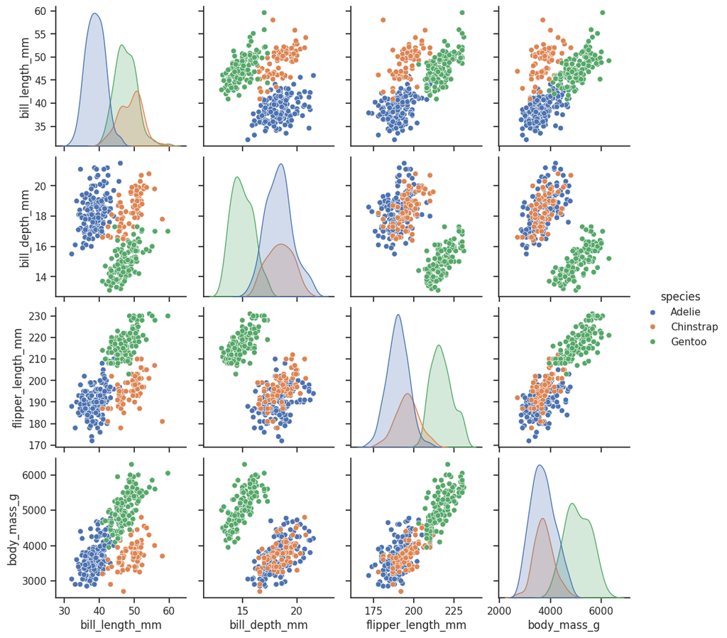

```python
## Type code here for the part 1 ##
import seaborn as sns
sns.set_theme(style="ticks")

df = sns.load_dataset("penguins")
sns.pairplot(df, hue="species")
```

### Is there any combination of features that can separate the three classes? If so, which features? If not, which are the closest?

Yes, the separate of the classes lie in the separation between the scatterplot. Each of the `bill_length_mm` plots, first row, seem to show adequate separate between each of the classes. `bill_depth_mm` vs. `bill_length_mm` also shows adequate separation as well. Lastly, `body_mass_g` vs. `bill_length_mm` also is pair of features that can separate the classes

# **2. Module 4 Note this is a Collaborative Problem**

*30 Points Total*  
In this problem, implement code to use the Mahalanobis Distance on the Iris dataset. You may NOT use the built-in function in Python.

1. [10 points] Using all four features, calculate the 50 distances for the Setosa class.
2. [5 points] Calculate the range (min and max) of the 50 Mahalanobis distance values. What is the delta between the min and the max?
3. [10 points] If you remove the observation with the largest distance, do the remaining distances appear to be closer together? After removing the observation with the largest distance, recalculate the ranges with the updated mean and covariance. Does removing the observation with the largest Mahalanobis distance provide a smaller range between the min and max?
4. [5 points] Given your findings, describe what was accomplished following the method above this data point from the dataset.

#### Part 1

First we can filter the dataframe to only see the `setosa` species. Also we would only like to see the values and filter out the column `species` for data manipulation

```python
## Type code here for part 1 ##
setosa_df = iris_df[iris_df["species"] == "setosa"]
setosa_df = setosa_df.drop(columns=["species"])
setosa_values = setosa_df.values
```

We can now create our own homegrown implementation of the mahalanobis distance after calculating the mean, covariance, and inverse covariance of the passed data. We will use these values to follow the formulation below:

$$mahalanobis = \sqrt{(x - \mu) \Sigma^{-1} (x - \mu)^T}$$

```python
def create_mahalanobis_distance(df_values):
    data = deepcopy(df_values)
    n = data.shape[0]
    p = data.shape[1]

    mu = np.mean(data, axis=0, keepdims=True)
    #rowvar change since observation are in the rows
    cov = np.cov(data, rowvar=False)
    inv_cov = np.linalg.inv(cov)
    # compute the squared malanobis distance, cap the minimum to only positive values
    mahalanobis_distance = np.sqrt(np.maximum((data - mu) @ inv_cov @ (data - mu).T,0)).diagonal()
    return mahalanobis_distance
```

```python
setosa_mahalanobis = create_mahalanobis_distance(setosa_values)
setosa_mahalanobis
```

```
array([0.66698442, 1.39300256, 1.14590085, 1.29205482, 0.9252263 ,
       1.91920834, 1.85193573, 0.54070921, 1.72628655, 1.66478036,
       1.35215307, 1.42359509, 1.61069941, 2.68373139, 3.20044667,
       2.73111366, 2.34944412, 0.80175606, 2.26334089, 1.28495791,
       2.22859256, 1.61362928, 3.34666234, 2.72761422, 3.09786973,
       1.85747736, 1.59756697, 0.86192245, 1.11047426, 1.45059611,
       1.34678509, 2.25139998, 2.8681089 , 2.3447252 , 1.66478036,
       1.80985963, 2.37067817, 1.66478036, 1.82105861, 0.70197087,
       1.29188685, 3.5536989 , 2.08163126, 3.46376956, 2.93230434,
       1.50040864, 1.70256269, 1.23882101, 1.11328423, 0.65873036])
```

Let's check this against scipy's implementation of the mahalanobis distance!

```python
from scipy.spatial import distance
mean = np.mean(setosa_values, axis=0)
covariance_matrix = np.cov(setosa_values, rowvar=False)
inv_covariance_matrix = np.linalg.inv(covariance_matrix)

mahalanobis_distance = [distance.mahalanobis(observation, mean, inv_covariance_matrix) for observation in setosa_values]
mahalanobis_distance
```

```
[0.6669844177020008,
 1.3930025560574884,
 1.1459008507832444,
 1.2920548163576284,
 0.9252262956748515,
 1.9192083413443877,
 1.8519357290245482,
 0.5407092054221374,
 1.7262865478623317,
 1.6647803569931081,
 1.3521530691248411,
 1.423595094849263,
 1.6106994068043785,
 2.683731394102202,
 3.2004466725467298,
 2.7311136604783943,
 2.349444116800975,
 0.8017560590798836,
 2.263340885775492,
 1.2849579142144503,
 2.2285925632952117,
 1.6136292804662589,
 3.3466623416562813,
 2.727614223898756,
 3.097869728969683,
 1.8574773630475796,
 1.5975669740432124,
 0.8619224508068133,
 1.1104742572431077,
 1.450596106348239,
 1.3467850901038192,
 2.2513999833891125,
 2.8681088967202335,
 2.3447252026575867,
 1.6647803569931081,
 1.8098596252263643,
 2.3706781679537627,
 1.6647803569931081,
 1.8210586104296862,
 0.7019708665640318,
 1.2918868467971938,
 3.5536988963324396,
 2.0816312580474396,
 3.463769562507756,
 2.932304343842135,
 1.5004086384356983,
 1.7025626894786368,
 1.2388210063460579,
 1.1132842316044038,
 0.6587303588154946]
```

Is there a difference between our approach and the implementation in scipy?

```python
difference_mahalanobis = mahalanobis_distance - setosa_mahalanobis
difference_mahalanobis
```

```
array([ 0.00000000e+00,  0.00000000e+00,  0.00000000e+00,  2.22044605e-16,
        0.00000000e+00, -2.22044605e-16,  0.00000000e+00,  0.00000000e+00,
        0.00000000e+00,  2.22044605e-16,  0.00000000e+00,  0.00000000e+00,
       -2.22044605e-16,  0.00000000e+00,  0.00000000e+00,  4.44089210e-16,
        0.00000000e+00,  0.00000000e+00,  0.00000000e+00,  0.00000000e+00,
        0.00000000e+00,  0.00000000e+00,  0.00000000e+00,  0.00000000e+00,
        0.00000000e+00,  0.00000000e+00,  2.22044605e-16,  0.00000000e+00,
        0.00000000e+00, -2.22044605e-16,  0.00000000e+00,  0.00000000e+00,
        0.00000000e+00,  0.00000000e+00,  2.22044605e-16,  0.00000000e+00,
        0.00000000e+00,  2.22044605e-16,  0.00000000e+00,  0.00000000e+00,
        0.00000000e+00,  0.00000000e+00,  0.00000000e+00, -4.44089210e-16,
        0.00000000e+00,  0.00000000e+00,  0.00000000e+00,  0.00000000e+00,
        0.00000000e+00,  0.00000000e+00])
```

Within in numerical precision, there is no difference. So, we can conclude that we implemented mahalanobis distance appropriately!

#### Part 2

```python
min_malahanobis_setosa = np.min(setosa_mahalanobis)
max_malahanobis_setosa = np.max(setosa_mahalanobis)

range_malahanobis_setosa = max_malahanobis_setosa - min_malahanobis_setosa
range_malahanobis_setosa
```

```
3.0129896909103024
```

What is the maximum for the whole dataset?

```python
max_malahanobis_setosa
```

```
3.5536988963324396
```

Also the minimum?

```python
min_malahanobis_setosa
```

```
0.5407092054221374
```

#### Part 3

```python
setosa_remove_max_df = setosa_df.drop(index= np.argmax(max_malahanobis_setosa))
```

Recalculate the malahanobis distances based on this new dataset

```python
new_setosa_mahalanobis = create_mahalanobis_distance(setosa_remove_max_df.values)
new_setosa_mahalanobis
```

```
array([1.38013599, 1.13623906, 1.27339791, 0.92489802, 1.89535927,
       1.82847778, 0.5390951 , 1.70408027, 1.65227722, 1.35109978,
       1.40495211, 1.60001728, 2.66003785, 3.18969141, 2.70609061,
       2.32813621, 0.79448608, 2.24206687, 1.27030293, 2.20729521,
       1.59218978, 3.31821403, 2.69689375, 3.06289963, 1.83643754,
       1.57498605, 0.86307787, 1.11171646, 1.43043985, 1.32803482,
       2.22632991, 2.84820855, 2.33533575, 1.65227722, 1.8014304 ,
       2.36158106, 1.65227722, 1.79962071, 0.70175128, 1.28074088,
       3.51460882, 2.05820636, 3.42710832, 2.89932221, 1.48042193,
       1.68644336, 1.22299441, 1.11398908, 0.66189184])
```

```python
new_max_malahanobis_setosa = np.max(new_setosa_mahalanobis)
new_max_malahanobis_setosa
```

```
3.5146088187318156
```

Ok, what is the new range?

```python
new_min_malahanobis_setosa = np.min(new_setosa_mahalanobis)
new_min_malahanobis_setosa
```

```
0.5390951013136559
```

```python
new_range_malahanobis_setosa = new_max_malahanobis_setosa - new_min_malahanobis_setosa
new_range_malahanobis_setosa
```

```
2.97551371741816
```

```python
range_malahanobis_setosa - new_range_malahanobis_setosa
```

```
0.0374759734921426
```

```python
max_malahanobis_setosa - new_max_malahanobis_setosa
```

```
0.039090077600623996
```

```python
min_malahanobis_setosa - new_min_malahanobis_setosa
```

```
0.0016141041084815066
```

# **3. Module 4 Note this is not a Collaborative Problem**

*20 Points Total*

In this problem we would like to introduce you to data transformations that can be used in order to generate features and extract components of images. For this problem you will be working with the wavelet transform. You may use the built-in function for this. Please follow the steps outlined below.

1. [2 points] Read in the MNIST dataset.
2. [2 points] Reshape the arrays in order to visualize each image in the dataset (in the MNIST dataset, each row represents a 28x28 image).
3. [2 points] Find an index from the MNIST dataset that holds an image for the number 7, we will use this in the subsequent steps.
4. [6 points] Perform a wavelet transform on this image and retain only the vertical and diagonal components of this image.
5. [6 points] Perform the inverse transform to revert back to an image.
6. [2 points] Plot the image (using plt.imshow) and provide an analysis of what was accomplished in this problem.

#### Part 1

```python
## Type code here for part 1 ##
mnist_df = pd.read_csv("train.csv")
mnist_values = mnist_df.values
```

```python
mnist_df
```

|  | label | pixel0 | pixel1 | pixel2 | pixel3 | pixel4 | pixel5 | pixel6 | pixel7 | pixel8 | ... | pixel774 | pixel775 | pixel776 | pixel777 | pixel778 | pixel779 | pixel780 | pixel781 | pixel782 | pixel783 |
| --- | --- | --- | --- | --- | --- | --- | --- | --- | --- | --- | --- | --- | --- | --- | --- | --- | --- | --- | --- | --- | --- |
| 0 | 1 | 0 | 0 | 0 | 0 | 0 | 0 | 0 | 0 | 0 | ... | 0 | 0 | 0 | 0 | 0 | 0 | 0 | 0 | 0 | 0 |
| 1 | 0 | 0 | 0 | 0 | 0 | 0 | 0 | 0 | 0 | 0 | ... | 0 | 0 | 0 | 0 | 0 | 0 | 0 | 0 | 0 | 0 |
| 2 | 1 | 0 | 0 | 0 | 0 | 0 | 0 | 0 | 0 | 0 | ... | 0 | 0 | 0 | 0 | 0 | 0 | 0 | 0 | 0 | 0 |
| 3 | 4 | 0 | 0 | 0 | 0 | 0 | 0 | 0 | 0 | 0 | ... | 0 | 0 | 0 | 0 | 0 | 0 | 0 | 0 | 0 | 0 |
| 4 | 0 | 0 | 0 | 0 | 0 | 0 | 0 | 0 | 0 | 0 | ... | 0 | 0 | 0 | 0 | 0 | 0 | 0 | 0 | 0 | 0 |
| ... | ... | ... | ... | ... | ... | ... | ... | ... | ... | ... | ... | ... | ... | ... | ... | ... | ... | ... | ... | ... | ... |
| 41995 | 0 | 0 | 0 | 0 | 0 | 0 | 0 | 0 | 0 | 0 | ... | 0 | 0 | 0 | 0 | 0 | 0 | 0 | 0 | 0 | 0 |
| 41996 | 1 | 0 | 0 | 0 | 0 | 0 | 0 | 0 | 0 | 0 | ... | 0 | 0 | 0 | 0 | 0 | 0 | 0 | 0 | 0 | 0 |
| 41997 | 7 | 0 | 0 | 0 | 0 | 0 | 0 | 0 | 0 | 0 | ... | 0 | 0 | 0 | 0 | 0 | 0 | 0 | 0 | 0 | 0 |
| 41998 | 6 | 0 | 0 | 0 | 0 | 0 | 0 | 0 | 0 | 0 | ... | 0 | 0 | 0 | 0 | 0 | 0 | 0 | 0 | 0 | 0 |
| 41999 | 9 | 0 | 0 | 0 | 0 | 0 | 0 | 0 | 0 | 0 | ... | 0 | 0 | 0 | 0 | 0 | 0 | 0 | 0 | 0 | 0 |

42000 rows × 785 columns

#### Part 2

```python
mnist_labels = mnist_values[0][:]
```

Now, we can reshape each of these rows to get a 28 x 28 matrix for displaying

```python
mnist_numbers = [row[:784].reshape(28,28) for row in mnist_values]
```

Let's display one of these numbers to make sure we did this right!

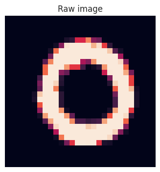

```python
plt.figure(figsize=(12, 4))

plt.imshow(mnist_numbers[1])
plt.title("Raw image")
plt.axis('off')

plt.show()
```

We should see `0` in the second index of the `mnist_labels` list

```python
mnist_labels[1]
```

```
0
```

#### Part 3

We can find the number seven by using the label column in our dataframe and take the first element that appears in our list

```python
## Type code here for part 3 ##
seven_index = mnist_df.index[mnist_df["label"] == 7].tolist()[0]
seven_index
```

```
6
```

Let's plot the 6th index to make sure we get the number `7`

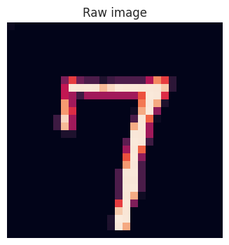

```python
plt.figure(figsize=(12, 4))

plt.imshow(mnist_numbers[6])
plt.title("Raw image")
plt.axis('off')

plt.show()
```

Now we have the number seven displayed!

```python
seven = mnist_numbers[6]
```

#### Part 4

We can perform the wavelet transform to see the reduction of the image

```python
coeff = pywt.dwt2(seven, "haar")
_, (_, c_vertical, c_diagonal) = coeff
```

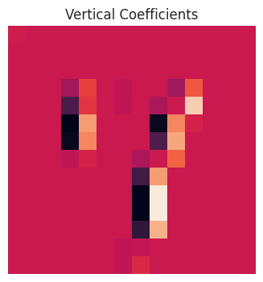

```python
plt.figure(figsize=(12, 4))

plt.imshow(c_vertical)
plt.title("Vertical Coefficients")
plt.axis('off')

plt.show()
```

This plot helps to show the High-frequency components that show the average change in the vertical pixels

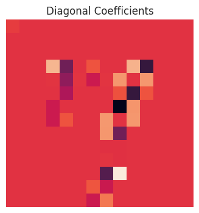

```python
plt.figure(figsize=(12, 4))

plt.imshow(c_diagonal)
plt.title("Diagonal Coefficients")
plt.axis('off')

plt.show()
```

Similarly, the cofficients on the diagonal help to show the average differences between the pixels on the diagonal

```python
reduced_coeff = _, (_, c_vertical, c_diagonal)
```

```python
reduced_coeff[1][2]
```

[output not shown]

[output cut: 15 more lines]

```
       [ 0.00000000e+00,  0.00000000e+00,  0.00000000e+00,
         0.00000000e+00,  0.00000000e+00,  0.00000000e+00,
         0.00000000e+00, -5.00000000e+01,  6.05000000e+01,
         0.00000000e+00,  0.00000000e+00,  0.00000000e+00,
         0.00000000e+00,  0.00000000e+00],
       [ 0.00000000e+00,  0.00000000e+00,  0.00000000e+00,
         0.00000000e+00,  0.00000000e+00,  0.00000000e+00,
         1.05000000e+01, -1.05000000e+01,  0.00000000e+00,
         0.00000000e+00,  0.00000000e+00,  0.00000000e+00,
         0.00000000e+00,  0.00000000e+00],
       [ 0.00000000e+00,  0.00000000e+00,  0.00000000e+00,
         0.00000000e+00,  0.00000000e+00,  0.00000000e+00,
        -1.00000000e+01,  2.05000000e+01,  0.00000000e+00,
         0.00000000e+00,  0.00000000e+00,  0.00000000e+00,
         0.00000000e+00,  0.00000000e+00]])
```

```python
## Type code here for part 5 ##
reconstruct_seven = pywt.idwt2(reduced_coeff, "haar")
```

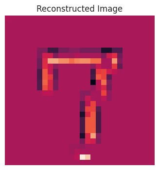

```python
## Type code here for part 6 ##

plt.figure(figsize=(12, 4))

plt.imshow(reconstruct_seven)
plt.title("Reconstructed Image")
plt.axis('off')

plt.show()
```

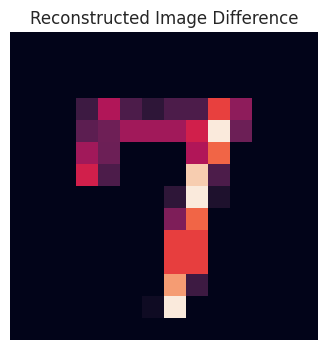

```python
plt.figure(figsize=(12, 4))

plt.imshow(seven - reconstruct_seven)
plt.title("Reconstructed Image Difference")
plt.axis('off')

plt.show()
```

# **4. Module 5 Note this is a Collaborative Problem**

*20 Points Total*

In this problem we would like to familiarize you with a basic example of a goal based agent. A game like rock paper scissors is typically played between two players and has a clearly defined set of rules for a win, draw, and loss. Since it is impossible (acknowledging that studies have been preformed to use behavior to attempt a prediction - but we will ignore that for the purpose of this exercise) to predict an opponent's move, we will assume that the user will input a value, the computer will see this input then choose from a set of rules the correct response play, acting as a simple goal based agent.

Instructions on how to play: https://www.wikihow.com/Play-Rock,-Paper,-Scissors

For this problem, you will fill in the rules (in if-then-else format) to the function in the cell below. The proceeding cell should then be run to play a game with the computer in which the computer agent should win every time.

```python
## Set Rock = 1, Paper = 2, Scissors = 3
## The funtion should read in the player_move and return the appropriate agent_play that will win the round
import random
def goal_based_agent(player_move=None):
    rock = 1
    paper = 2
    scissors = 3
    if player_move == rock:
        return paper
    if player_move == paper:
        return scissors
    if player_move == scissors:
        return rock
```

```python
## Set Rock = 1, Paper = 2, Scissors = 3
## The program will receive player input for the number of rounds to be played: suggested to use 5 so that you may test your implementation
import sys

num_rounds = int(input("Enter number of rounds to be played: "))
curr_round = 1
win_counter = 0
while curr_round <= num_rounds:
    print("Enter choice \n 1 for Rock, \n 2 for paper, and \n 3 for scissor \n")

    # take the input from user
    player_move = int(input("User turn: "))

    if player_move == 1 or player_move == 2 or player_move == 3:
        if player_move == 1:
            choice_name = 'Rock'
        elif player_move == 2:
            choice_name = 'Paper'
        elif player_move == 3:
            choice_name = 'Scissor'

        print("Player move is: ", choice_name)

        AI_move = goal_based_agent(player_move) ## this is where your function is called, player_move which is an input is sent to your agent and returns the correct AI move

        if AI_move == 1:
            AI_play = 'Rock'
        elif AI_move == 2:
            AI_play = 'Paper'
        elif AI_move == 3:
            AI_play = 'Scissor'

        print("AI move is: ", AI_play)

        win = None
        if player_move == 1 and AI_move == 2:
            win = 1
        elif player_move == 2 and AI_move == 3:
            win = 1
        elif player_move == 3 and AI_move == 1:
            win = 1
        else:
            win = 0

        if win == 1:
            win_counter = win_counter + 1
            print("AI wins this round!")
        else:
            print("AI lost this round!")

        print("Round Number: ", curr_round)

        curr_round = curr_round + 1

    else:
        print("Invalid player input, GAME OVER")
        sys.exit(1)

print("\n\nGame Concluded")
print("Round Number: ", curr_round - 1)
print("Number of Wins: ", win_counter)
print("Number of Losses: ", curr_round - win_counter - 1)

if curr_round - win_counter == 1:
    print('Well done!')
else:
    print('You need to fix your goal based agnet!')
```

```
Enter choice
 1 for Rock,
 2 for paper, and
 3 for scissor

Player move is:  Rock
AI move is:  Paper
AI wins this round!
Round Number:  1
Enter choice
 1 for Rock,
 2 for paper, and
 3 for scissor

Player move is:  Paper
AI move is:  Scissor
AI wins this round!
Round Number:  2
Enter choice
 1 for Rock,
 2 for paper, and
 3 for scissor

Player move is:  Scissor
AI move is:  Rock
AI wins this round!
Round Number:  3
Enter choice
 1 for Rock,
 2 for paper, and
 3 for scissor

Player move is:  Rock
AI move is:  Paper
AI wins this round!
Round Number:  4
Enter choice
 1 for Rock,
 2 for paper, and
 3 for scissor

Player move is:  Paper
AI move is:  Scissor
AI wins this round!
Round Number:  5


Game Concluded
Round Number:  5
Number of Wins:  5
Number of Losses:  0
Well done!
```

# References

[1] Bishop, Christopher M., Pattern Recognition and Machine Learning, Springer, 2006,  
[2] Dillon, and Goldstein, M.. Multivariate Analysis Methods and Applications, John Wiley, 1984 https://www.microsoft.com/en-us/research/uploads/prod/2006/01/Bishop-Pattern-Recognition- and-Machine-Learning-2006.pdf  
[3] Duin, Robert P.W., Tax, David and Pekalska, Elzbieta, PRTools, http://prtools.tudelft.nl/  
[4] Fisher, R.A., The use of Multiple Measurements in Taxonomic Problems, Annals of Human Genetics, Vol. 7, Issue 2, pp. 179-188, 1936  
[5] Hotelling, H., Analysis of a complex of statistical variables into principal components, Jour- nal of Educational Psychology, Number 24, pp. 417–441, 1933  
[6] Rao, K. P. and Yip, P., Discrete Cosine Transform Algorithms, Advantages, Applications, San Diego, CA: Academic Press, Inc., 1990